# Régression_logistique

## Régression Logistique

Les variables d’entrées sont quantitatives ou qualitatives et $Y \in \{0, 1\}$.

- Les variables qualitatives sont recodées par les indicatrices des modalités et $X = (X_1, . . . , X_p)$ $\in \mathbb{R}$ avec $X_j$ quantitative ou binaire.
- En régression logistique, on s’intéresse à la loi de $Y$ sachant $X$ qui est une loi de Bernoulli de paramètre $p$ avec :

$$ \mathbb{P}(Y = 1|X = x) = \pi $$

et

$$ \mathbb{P}(Y = 0|X = x) = 1 − \pi $$

- On fait l’hypothèse que la probabilité $\mathbb{P}(Y = 1|X = x) = \pi $ est **une fonction logistique d’un score linéaire**

$$ \beta_0 +  \beta_1X_1 + . . . +  \beta_pX_p = \in \mathbb{R} $$

et la fonction logistique $f : \mathbb{R} \to [0, 1]\ $ est définie par :

$$ f(z) = \frac{exp(z)}{1 + exp(z)}. $$

```python
# fonction sigmoid
import numpy as np
def sig(x):
    return 1/(1 + np.exp(-x))
```

```python
import numpy as np
def sig2(x):
    return np.exp(x)/(1 + np.exp(x))
```

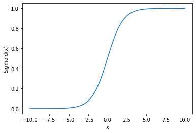

```python
# plot
import numpy as np
import matplotlib.pyplot as plt
x = np.linspace(-10, 10, 50)
p = sig(x)
plt.xlabel("x")
plt.ylabel("Sigmoid(x)")
plt.plot(x, p)
plt.show()
```

- On modélise donc la probabilité à posteriori $\pi$ par :

$$ \mathbb{P}(Y = 1|X = x)=\frac{exp(\beta_0+\sum_{j=1}^{P}\beta_j X_j )}{1 + exp(\beta_0+\sum_{j=1}^{P}\beta_j X_j)} $$

- En utilisant **la fonction logit** le score linéaire est alors :

$$ logit(p)=log(\frac{\pi }{1- \pi })=\beta_0+\sum_{j=1}^{P}\beta_j X_j $$

### Estimation des paramètres

- Paramètres inconnus estimés par maximum de vraisemblance :

$$ (\beta_0, \beta_1, . . .,  \beta_p) $$

- Log-vraissemblance (conditionnelle) de l’échantillon $(X1,Y1), . . . , (Xn,Yn)$

> $$ l(\beta_0, \beta_1, . . .,\beta_p) = log\Pi_{i=1}^{n}\mathbb{P}(Y = y_i|X = x_i)=log\Pi_{i=1}^{n} \pi _i^{y_i} (1-\pi _i)^{1-y_i} $$

> avec $\pi_i = \mathbb{P}(Y = y_i|X = x_i)= \frac{exp(\beta_0+\sum_{j=1}^{P}\beta_j X_ij )}{1 + exp(\beta_0+\sum_{j=1}^{P}\beta_j X_ij)}$

### Algorithme itératif

- L’estimateur du maximum de vraissemblancede   n’a pas de forme explicite. Les logiciels utilisent donc des algorithmes d’optimisation pour estimer les paramètres $(\beta_0, \beta_1, . . .,\beta_p)$ sur les données d’apprentissage.
- L’algorithme souvent utilisé est celui de Newton-Raphson qui est une méthode itérative de type gradient basée sur la relation suivante :

$$ \beta^{(t)}=\beta^{(t-1)}- (\frac{\partial^2 l(\beta)}{\partial\beta\partial\beta^T}|_{\beta^{(t-1)}})^{-1} \frac{\partial l(\beta)}{\partial\beta}|_{\beta^{(t-1)}} $$

### Régle de classification

- La règle de classification g affecte alors une nouvelle observation x à la classe 1 si

$$ \pi =\frac{exp(\hat{\beta}_0+\sum_{j=1}^{P}\hat{\beta}_j X_j )}{1 + exp(\hat{\beta}_0+\sum_{j=1}^{P}\hat{\beta}_j X_j)} $$

est supérieur à 0.5. Elle est affectée à la classe 0 sinon.

### Cas de classes multiples $(K > 2)$

- La régression logistique peut s’étendre au cas de classes multiples. On parle alors de régression logistique multinomiale.
- On a maintenant $Y \in \{1, . . . ,K\}$ et on note $X = (1, X_1, . . . , X_p)$.
- Le modèle prend la forme

$$ log(\frac{\mathbb{P}(Y = 1|X = x)}{\mathbb{P}(Y = K|X = x)})= x^T\beta_1 $$$$ log(\frac{\mathbb{P}(Y = 2|X = x)}{\mathbb{P}(Y = K|X = x)})= x^T\beta_2 $$$$ : : $$$$ log(\frac{\mathbb{P}(Y = K-1|X = x)}{\mathbb{P}(Y = K|X = x)})= x^T\beta_{K-1} $$

avec  $\beta_{1},\beta_{2} . . ,\beta_{K-1}$ des vecteurs de $\mathbb{R}^{p+1}$.

Les $K − 1$ vecteurs  $\beta_{k}$ sont estimés par maximum de vraisemblance sur les données d’apprentissage.

- Les probabilités à posteriori sont alors :

$$ \mathbb{P}(Y = K|X = x)=\frac{1}{1+\sum_{l=1}^{K-1} exp(x^T\beta_l)} $$$$ \mathbb{P}(Y = 1|X = x)=\frac{exp(x^T\beta_1)}{1+\sum_{l=1}^{K-1} exp(x^T\beta_l)} $$$$ : $$$$ \mathbb{P}(Y = K-1|X = x)=\frac{exp(x^T\beta_{K-1)}}{1+\sum_{l=1}^{K-1} exp(x^T\beta_l)} $$

- La règle de classification affecte alors une nouvelle observation x à la classe la plus probable à posteriori.

### Tester la significativité d’un coefficient

- Le test le plus immédiat est celui de Wald. Il suffit de regarder les p-value associées à chaque variable dans le résumé des résultats.
- On teste l’effet de chaque variable en testant l’hypothèse

$$H_0: \beta_j=0$$

- On rejette l’hypothèse $H_0$ dès que la p-valeur de $H_0$ est trop faible.

En effet : $P(Observations|H_0) = p-valeur$.

Si la p-valeur est trop faible, alors aux vues de ces observations, l’hypothèse $H_0$ est peu vraisemblable et par conséquent le coefficient $\beta_j$ est significativement non nul.

### Tests de significativité globale de la régression

#### Test du rapport de vraisemblance :

> - Rapport de vraisemblance = Déviance du modèle trivial (réduit à la constante) – déviance du modèle étudié
> - déviance est égale à (-2) x log-vraisemblance. $Déviance=-2\ln(L)$
> - DDL = écart entre les deux DDL
> - P-VALUE = loi du KHI-2 à DDL degrés de liberté

#### Comparaisons des critères AIC et BIC

Une autre approche méconnue pour évaluer la qualité globale du modèle consiste à confronter les critères AIC (Akaike) ou BIC (Schwartz) du modèle étudié avec ceux du modèle trivial (null modèle).

- AIC : le critère d'information d'Akaike s'écrit comme suit : $$\mathit{AIC}=2k-2\ln(L)$$ où k est le nombre de paramètres à estimer du modèle et L est le maximum de la fonction de vraisemblance du modèle
- BIC: se définit comme suit :

$$\mathit{BIC}=-2\ln(L)+\ln(n)k$$

avec n le nombre d'observations dans l'échantillon étudié et k le nombre de paramètres

- Le BIC a la particularité de pénaliser davantage la complexité (le nombre de paramètres à estimer).
- Si (AIC_modèle < AIC_null), nous pouvons conclure que notre modèle est globalement pertinent (idem pour le critère BIC).

#### Pseudo $R^2$ :

Les pseudo-R² sont des indicateurs similaires dans l’esprit au R² de la régression linéaire. Il sont basés sur la confrontation entre la log-vraisemblance du modèle et de celle du modèle trivial composé uniquement de la constante (null model)

> - R² de McFadden: 1-(Log-vraisemblance du modèle/log-vraisemblance du null modèle)
> - R² de Cox et Snell : 1-(exponenielle (Log-vraisemblance du du null modèle)/exponenielle (log-vraisemblance du modèle))^(2/n)

### Interprétation de la régression logstique (odds)

- Si Y est une variable de Bernoulli de paramètre $\pi$, alors l’odds est égal à  $\frac{\pi}{1-\pi}$ , la cote ou chance de gain.
- **La régression logistique s’interprète comme la recherche d’une modélisation linéaire du "log odds"**.

On va chercher $\beta$  tel que $$ \frac{\pi_x}{1-\pi_x}=exp(x^T\beta) $$

La régression logistique s’exprime généralement sous la forme

$$ \frac{\pi_{x_1,...,x_p}}{1-\pi_{x_1,...,x_p}}=exp(\beta_0+\sum_{j=1}^{P}\beta_j X_j) $$

> - Si $\beta_j= 0$, alors l’odds ratio ne dépend pas de $x_j$ .
> - Un incrément de 1 dans $x_j$ correspond à un incrément de $exp(\beta_j)$ dans l’odds ratio
> - Si  $ \beta_j> 0$, alors un incrément de 1 dans $x_j$ entraîne une augmentation de $exp(\beta_j)$  du risque (ou de la chance) que Y prenne la valeur 1.

> $$ \frac{\frac{\pi_{x_1,...,x_j+1,...,x_p}}{1-\pi_{x_1,...,x_j+1,...,x_p}}}{\frac{\pi_{x_1,...,x_p}}{1-\pi_{x_1,...,x_p}}} =exp(\beta_j) $$

## Conclusion

- L a régression logistique est une méthode de classification trés utilisée, notamment pourK = 2.
- LDA est utile quand n est petit ou les classes sont bien séparées, e t l’hypothèse sur la distribution gaussienne des variables est raisonnable. Egalement elle marche bien quand K>2
- Le classifieur bayesien naif est utile quand p est très grand.

### Régression logistique versus LDA

- Pour un problèm à deux classes on peut montrer que

$$ logit(p)=log(\frac{\pi }{1- \pi })=\beta_0+\sum_{j=1}^{P}\beta_j X_j $$

- Elle a la même forme que la régrssion logistique
- La différence entre les deux methodes réside dans l’estimation des paramètres
- La régression logistique utilise la vraissemblance conditionnelle basée sur Pr(Y/X) (une méthode discriminative).
- LDA utilise la vraissemblance basée sur Pr(X,Y))(une méthode générative).
- Malgré ces différences en partique, elles donnent des résultats similaires
- La régression logistique permet également d’ajuster des frontières quadratiques comme la méthode LDA, en injectant explicitement des terms quadratiques dans le modèle